# PPAR/RXR Motif Alignment (42 human-source motifs)

Eli Brouwer

2026-09-30

This replaces `Objective1_motif_alignment_CISBP_additions.Rmd` for the final run. The motif set is the 42 human-source PPAR/RXR position weight matrices (11 JASPAR 2026, 6 HOCOMOCO CORE, 25 CIS-BP 3.10) selected in `Motifs_update_2026-09-30/` (mouse-derived and unclear-species motifs were excluded). The plotting, canvas and export functions are reused from the earlier script; what changed is

- the loader (one combined MEME file, selected by `motif_inventory_human_only.csv`),
- the display order (derived from the inventory instead of typed by hand), and
- the manual alignment table: start column and orientation are now **derived by rule** for every motif (see below) and validated against the hand-curated table for the 15 motifs that both sets share.

```r
# Change motif_dir if the repository is checked out somewhere else.
motif_dir <- "C:/Users/brouw/OneDrive - Universiteit Utrecht/Master Bioinformatics/Minor internship/PPAR_RXR_motifs_Hocomoco_Jaspar/Motifs_update_2026-09-30"
output_directory <- file.path(motif_dir, "alignment_human42")
meme_export_directory <- file.path(output_directory, "meme_export")
dir.create(meme_export_directory, recursive = TRUE, showWarnings = FALSE)
```

# 1 Load the 42 motifs

```r
inv <- read.csv(file.path(motif_dir, "motif_inventory_human_only.csv"),
                check.names = FALSE, fileEncoding = "UTF-8-BOM", stringsAsFactors = FALSE)
pfm_list <- importMatrix(file.path(motif_dir, "PPAR_RXR_human_only_combined.meme"))
names(pfm_list) <- sapply(pfm_list, function(m) m@name)
stopifnot(setequal(names(pfm_list), inv$motif_id), nrow(inv) == 42)

# display order: heterodimers, then PPARA, PPARD, PPARG, RXRA, RXRB, RXRG;
# within a group JASPAR, HOCOMOCO, CIS-BP
group_of <- ifelse(inv$category == "PPAR:RXR heterodimer", "BOTH", toupper(inv$name))
group_rank <- match(group_of, c("BOTH", "PPARA", "PPARD", "PPARG", "RXRA", "RXRB", "RXRG"))
db_rank <- match(sub(" .*", "", inv$database), c("JASPAR", "HOCOMOCO", "CIS-BP"))
inv <- inv[order(group_rank, db_rank, inv$motif_id), ]
inv$Family <- ifelse(grepl("::", inv$name), "BOTH", ifelse(grepl("^PPAR", toupper(inv$name)), "PPAR", "RXR"))

# motifs that were not part of the earlier 30-motif run get a trailing "*"
new_names <- inv$motif_id[inv$status == "NEW"]
pfm_list <- pfm_list[inv$motif_id]
```

# 2 Reference PPRE motif

A canonical PPRE (DR1) motif is the template: `AAAT`-`CAGGTCA`-`A`-`AGGTCA`, PPAR half-site under columns 6-11 and RXR half-site under columns 13-18.

```r
PPRE_mat <- matrix(c(
  1,1,1,0,0,1,0,0,0,0,1,1,1,0,0,0,0,1,  # A
  0,0,0,0,1,0,0,0,0,1,0,0,0,0,0,0,1,0,  # C
  0,0,0,0,0,0,1,1,0,0,0,0,0,1,1,0,0,0,  # G
  0,0,0,1,0,0,0,0,1,0,0,0,0,0,0,1,0,0   # T
), nrow = 4, byrow = TRUE)
rownames(PPRE_mat) <- c("A", "C", "G", "T")
ppre_motif <- new("pfm", mat = PPRE_mat, name = "PPRE motif")
```

# 3 Rule-based manual alignment

The earlier `manual_alignment` table was typed by hand (start column and reverse-complement flag per motif, anchored on the `AGGTCA`-like core). For 42 motifs this is done by rule instead:

```r
normalize_matrix <- function(mat) {
  mat <- mat[c("A", "C", "G", "T"), , drop = FALSE]
  mat[is.na(mat)] <- 0
  totals <- colSums(mat)
  informative <- totals > 0
  if (any(informative)) mat[, informative] <- sweep(mat[, informative, drop = FALSE], 2, totals[informative], "/")
  mat
}
reverse_complement_matrix <- function(mat) {
  mat <- mat[c("T", "G", "C", "A"), ncol(mat):1, drop = FALSE]
  rownames(mat) <- c("A", "C", "G", "T")
  mat
}
place_on_canvas <- function(mat, start, canvas_width) {
  end <- start + ncol(mat) - 1
  if (start < 1 || end > canvas_width) stop("Motif does not fit on canvas: ", start, "-", end)
  canvas <- matrix(0, 4, canvas_width, dimnames = list(c("A", "C", "G", "T"), seq_len(canvas_width)))
  canvas[, start:end] <- mat
  canvas
}

allowed <- rbind(c(1,0,1,0), c(0,0,1,0), c(0,0,1,0), c(0,0,0,1), c(0,1,0,0), c(1,0,0,0))  # R G G T C A
half_site_scores <- function(mat) {
  w <- ncol(mat)
  if (w < 6) return(numeric(0))
  vapply(seq_len(w - 5), function(i) mean(vapply(1:6, function(k) sum(mat[, i + k - 1] * allowed[k, ]), 0)), 0)
}
call_half_sites <- function(mat, threshold = 0.6) {
  s <- half_site_scores(mat)
  cand <- which(s >= threshold)
  cand <- cand[order(-s[cand])]
  kept <- integer(0)
  for (p in cand) if (all(abs(p - kept) >= 6)) kept <- c(kept, p)
  sort(kept)
}

rule_alignment <- function(motif_id, family) {
  mat <- normalize_matrix(pfm_list[[motif_id]]@mat)
  plus <- call_half_sites(mat)
  minus <- call_half_sites(reverse_complement_matrix(mat))
  use_rc <- length(minus) > length(plus) ||
    (length(minus) == length(plus) && length(plus) > 0 &&
       max(half_site_scores(reverse_complement_matrix(mat))) > max(half_site_scores(mat)) + 0.02)
  sites <- if (use_rc) minus else plus
  confident <- length(sites) > 0
  if (!confident) {                       # fall back to the best-scoring window on either strand
    s_plus <- half_site_scores(mat); s_rc <- half_site_scores(reverse_complement_matrix(mat))
    use_rc <- max(s_rc) > max(s_plus)
    sites <- which.max(if (use_rc) s_rc else s_plus)
  }
  anchor_site <- if (family == "RXR") tail(sites, 1) else sites[1]
  anchor_col <- if (family == "RXR") 13 else 6
  data.frame(Motif_name = motif_id, Start = anchor_col - anchor_site + 1, Reverse_complement = use_rc,
             Family = family, n_half_sites = length(sites), confident = confident, stringsAsFactors = FALSE)
}

manual_alignment <- do.call(rbind, Map(rule_alignment, inv$motif_id, inv$Family))
rownames(manual_alignment) <- NULL
shift <- 1 - min(c(manual_alignment$Start, 1))   # also keeps the PPRE reference (starts at column 1) on the canvas
manual_alignment$Start_unshifted <- manual_alignment$Start
manual_alignment$Start <- manual_alignment$Start + shift
cat("canvas shift applied:", shift, "columns\n")
```

```
## canvas shift applied: 0 columns
```

```r
cat("motifs without a confident half-site call:", sum(!manual_alignment$confident), "\n")
```

```
## motifs without a confident half-site call: 0
```

```r
write.csv(manual_alignment, file.path(output_directory, "manual_alignment_human42.csv"), row.names = FALSE)
manual_alignment
```

```
##             Motif_name Start Reverse_complement Family n_half_sites confident
## 1             MA0065.1     2              FALSE   BOTH            2      TRUE
## 2             MA1148.1     2              FALSE   BOTH            2      TRUE
## 3             MA1148.2     2              FALSE   BOTH            2      TRUE
## 4    PPARA_M10653_3.10     2              FALSE   PPAR            2      TRUE
## 5             MA1550.1     4              FALSE   PPAR            2      TRUE
## 6             MA1550.2     5              FALSE   PPAR            2      TRUE
## 7    PPARD_M05793_3.10     4              FALSE   PPAR            2      TRUE
## 8    PPARD_M05794_3.10     4              FALSE   PPAR            1      TRUE
## 9    PPARD_M05795_3.10     4              FALSE   PPAR            2      TRUE
## 10   PPARD_M05796_3.10     4              FALSE   PPAR            1      TRUE
## 11            MA0066.1     4              FALSE   PPAR            1      TRUE
## 12            MA0066.2     5              FALSE   PPAR            1      TRUE
## 13   PPARG_M02901_3.10     5              FALSE   PPAR            1      TRUE
## 14   PPARG_M10636_3.10     2              FALSE   PPAR            2      TRUE
```

[output cut: 71 more lines]

## 3.1 Check against the hand-curated table (15 shared motifs)

```r
hand <- data.frame(
  Motif_name = c("MA1148.1","MA1148.2","MA0065.1","MA1550.1","MA1550.2","MA0066.1","MA0066.2",
                 "RXRA.H13CORE.0.PS.A","RXRA.H13CORE.2.SM.B","RXRB.H13CORE.0.P.C","RXRB.H13CORE.1.SM.B",
                 "MA0855.1","MA1555.1","MA0856.1","MA1556.1"),
  Start_hand = c(2,2,2,4,5,4,5,10,5,6,4,5,12,5,12),
  RC_hand = c(rep(FALSE, 12), TRUE, FALSE, FALSE), stringsAsFactors = FALSE)
cmp <- merge(hand, manual_alignment[, c("Motif_name", "Start_unshifted", "Reverse_complement")], by = "Motif_name")
cmp$start_agrees <- cmp$Start_hand == cmp$Start_unshifted
cmp$rc_agrees <- cmp$RC_hand == cmp$Reverse_complement
cmp
```

```
##             Motif_name Start_hand RC_hand Start_unshifted Reverse_complement
## 1             MA0065.1          2   FALSE               2              FALSE
## 2             MA0066.1          4   FALSE               4              FALSE
## 3             MA0066.2          5   FALSE               5              FALSE
## 4             MA0855.1          5   FALSE               5              FALSE
## 5             MA0856.1          5   FALSE               5              FALSE
## 6             MA1148.1          2   FALSE               2              FALSE
## 7             MA1148.2          2   FALSE               2              FALSE
## 8             MA1550.1          4   FALSE               4              FALSE
## 9             MA1550.2          5   FALSE               5              FALSE
## 10            MA1555.1         12    TRUE              12               TRUE
## 11            MA1556.1         12   FALSE              12              FALSE
## 12 RXRA.H13CORE.0.PS.A         10   FALSE              10              FALSE
## 13 RXRA.H13CORE.2.SM.B          5   FALSE               5              FALSE
## 14  RXRB.H13CORE.0.P.C          6   FALSE               6              FALSE
```

[output cut: 17 more lines]

```r
cat(sum(cmp$start_agrees), "of", nrow(cmp), "start columns and", sum(cmp$rc_agrees), "of", nrow(cmp),
    "orientations reproduce the hand-curated table\n")
```

```
## 15 of 15 start columns and 15 of 15 orientations reproduce the hand-curated table
```

```r
write.csv(cmp, file.path(output_directory, "manual_alignment_validation_vs_hand_curated.csv"), row.names = FALSE)
```

# 4 Unsupervised alignment (pre-oriented)

`DNAmotifAlignment()` is run with `threshold = 0.5` (information-content cutoff for the columns that drive the alignment) and `minimalConsensus = 6`. The aligner may also reverse-complement motifs (`revcomp = TRUE`), but its choice depends on the order in which the motifs are passed in: with the same 42 motifs and threshold 0.5 a run in display order flipped 8 motifs (half-sites in the 3 most common columns: 64%, consensus information content 3.1 bits), a run in sheet order flipped 1 (91%, 6.3 bits), and random orders gave 1 to 10 flips (3.9 to 4.3 bits). The motifs are therefore oriented first with the half-site rule below and the aligner is run with `revcomp = FALSE`. With this setup the result is identical for every threshold from 0.2 to 0.6 and worse at 0.8 and above (`results/motif_alignment_human42/alignment_threshold_and_order_test.txt`), so 0.5 is kept.

```r
oriented_pfms <- pfm_list
for (i in seq_len(nrow(manual_alignment))) {
  if (manual_alignment$Reverse_complement[i]) {
    id <- manual_alignment$Motif_name[i]
    oriented_pfms[[id]]@mat <- reverse_complement_matrix(oriented_pfms[[id]]@mat)
  }
}
all_pfms <- c(oriented_pfms, list(`PPRE motif` = ppre_motif))
aligned_motifs <- DNAmotifAlignment(all_pfms, threshold = 0.5, minimalConsensus = 6,
                                    revcomp = rep(FALSE, length(all_pfms)))
strip_rc <- function(x) sub("\\(RC\\)$", "", x)
motif_names <- sapply(aligned_motifs, function(m) m@name)
indices <- match(strip_rc(c("PPRE motif", inv$motif_id)), strip_rc(motif_names))
stopifnot(!any(is.na(indices)))
aligned_motifs_order <- rev(aligned_motifs[indices])
for (i in seq_along(aligned_motifs_order)) {
  if (strip_rc(aligned_motifs_order[[i]]@name) %in% new_names)
    aligned_motifs_order[[i]]@name <- paste0(aligned_motifs_order[[i]]@name, " *")
}

# per-motif stack (same layout plotMotifLogoStack uses), with a yellow bar behind new motifs
highlighted_motif_stack <- function(pfms, ...) {
  n <- length(pfms); ht <- 1 / n; y0 <- 0.5 * ht; plot <- gList()
  for (i in seq_len(n)) {
    m <- pfms[[i]]
    logo <- plotMotifLogo(pfm = m, motifName = m@name, p = m@background, colset = m@color,
                          xlab = NA, newpage = FALSE, draw = FALSE,
                          margins = c(1.5, 4.1, 1.1, 0.1), ...)
    children <- if (grepl("\\*$", m@name)) {
      gList(rectGrob(y = unit(1, "npc") - unit(0.6, "lines"), height = unit(1.2, "lines"),
                     width = unit(0.98, "npc"), gp = gpar(fill = "#fff59d", col = NA, alpha = 0.8)), logo)
    } else logo
    plot <- gList(plot, gTree(children = children, vp = viewport(y = y0, height = ht)))
    y0 <- y0 + ht
  }
  plot
}

dev.control("enable")
grid.newpage()
grid.draw(highlighted_motif_stack(aligned_motifs_order, fontsize = 2, yaxis = FALSE, ylab = "", font = "Arial"))
recorded_alignment_plot <- recordPlot()
pdf(file.path(output_directory, "aligned_motifs_human42_threshold0.5_preoriented.pdf"), height = 26)
replayPlot(recorded_alignment_plot)
dev.off()
```

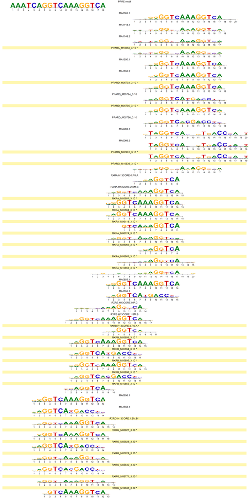

```r
grid.newpage()
grid.draw(highlighted_motif_stack(aligned_motifs_order, fontsize = 4, yaxis = FALSE, ylab = "", font = "Arial"))
```

```r
motifs_by_name <- pfm_list
canvas_width <- max(manual_alignment$Start + vapply(manual_alignment$Motif_name, function(n) ncol(motifs_by_name[[n]]@mat), 0) - 1)
manual_aligned_matrices <- lapply(seq_len(nrow(manual_alignment)), function(i) {
  mat <- normalize_matrix(motifs_by_name[[manual_alignment$Motif_name[i]]]@mat)
  if (manual_alignment$Reverse_complement[i]) mat <- reverse_complement_matrix(mat)
  place_on_canvas(mat, manual_alignment$Start[i], canvas_width)
})
names(manual_aligned_matrices) <- manual_alignment$Motif_name

# coverage-aware consensus, keeping columns covered by at least half of the motifs
n_motifs <- length(manual_aligned_matrices)
consensus_matrix <- matrix(0, 4, canvas_width, dimnames = list(c("A","C","G","T"), seq_len(canvas_width)))
position_coverage <- numeric(canvas_width)
for (position in seq_len(canvas_width)) {
  contributing <- vapply(manual_aligned_matrices, function(m) sum(m[, position]) > 0, logical(1))
  position_coverage[position] <- sum(contributing)
  if (any(contributing))
    consensus_matrix[, position] <- rowMeans(vapply(manual_aligned_matrices[contributing], function(m) m[, position], numeric(4)))
}
keep <- position_coverage >= ceiling(n_motifs / 2)
manual_consensus <- consensus_matrix[, keep, drop = FALSE]
manual_consensus <- sweep(manual_consensus, 2, colSums(manual_consensus), "/")
colnames(manual_consensus) <- seq_len(ncol(manual_consensus))
manual_pfm <- new("pfm", mat = manual_consensus, name = "Consensus from rule-based alignment")
```

[figure not shown]

```r
# Every motif is drawn on the shared canvas at its rule-derived start column (unoccupied columns are
# drawn as a uniform 0.25 background, i.e. blank), so the AGGTCA half-sites stack in the same columns.
canvas_to_pfm <- function(mat, name) {
  mat[, colSums(mat) == 0] <- 0.25
  new("pfm", mat = mat, name = name)
}
ppre_on_canvas <- place_on_canvas(normalize_matrix(PPRE_mat), 1 + shift, canvas_width)  # PPAR box at column 6 + shift
stack_pfms <- c(
  list(`PPRE motif` = canvas_to_pfm(ppre_on_canvas, "PPRE motif")),
  lapply(manual_alignment$Motif_name, function(id)
    canvas_to_pfm(manual_aligned_matrices[[id]], if (id %in% new_names) paste0(id, " *") else id))
)
dev.control("enable")
plotMotifLogoStack(rev(stack_pfms), fontsize = 3, yaxis = FALSE, ylab = "", font = "Arial")
```

```r
recorded_manual_plot <- recordPlot()
# saved as its own file (same record/replay approach as the unsupervised stack above)
pdf(file.path(output_directory, "manual_alignment_human42_stack.pdf"), width = 14, height = 34)
replayPlot(recorded_manual_plot)
dev.off()
```

```r
aligned_names <- sapply(aligned_motifs, function(m) m@name)
unsupervised_idx <- match(strip_rc(manual_alignment$Motif_name), strip_rc(aligned_names))
stopifnot(!any(is.na(unsupervised_idx)))
unsupervised_mats <- lapply(aligned_motifs[unsupervised_idx], function(m) m@mat)
common_width <- unique(vapply(unsupervised_mats, ncol, integer(1)))
stopifnot(length(common_width) == 1)
unsupervised_stack <- array(NA_real_, dim = c(4, common_width, length(unsupervised_mats)))
for (i in seq_along(unsupervised_mats)) unsupervised_stack[, , i] <- unsupervised_mats[[i]]
unsupervised_consensus <- apply(unsupervised_stack, c(1, 2), mean, na.rm = TRUE)
unsupervised_consensus[is.nan(unsupervised_consensus)] <- 0.25
unsupervised_consensus <- sweep(unsupervised_consensus, 2, colSums(unsupervised_consensus), "/")
rownames(unsupervised_consensus) <- c("A", "C", "G", "T")
unsupervised_pfm <- new("pfm", mat = unsupervised_consensus, name = "Consensus from unsupervised alignment")
```

# 5 PPRE architecture validation figure

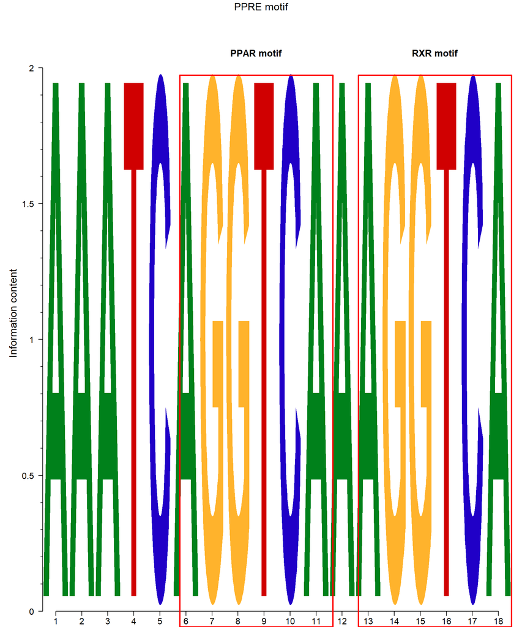

[figure not shown]

```r
ppre_pfm <- new("pfm", mat = normalize_matrix(PPRE_mat), name = "PPRE motif")
ppre_reference_grob <- grid::grid.grabExpr({
  plotMotifLogo(pfm = ppre_pfm, motifName = "PPRE motif", p = ppre_pfm@background, colset = ppre_pfm@color,
                yaxis = TRUE, ylab = "Information content", xlab = NA, margins = c(1.5, 4.1, 6.5, 1.0), newpage = FALSE)
  left_frac <- 0.10; right_frac <- 0.98; col_width <- (right_frac - left_frac) / 18
  ppar_box <- left_frac + c(5, 11) * col_width
  rxr_box  <- left_frac + c(12, 18) * col_width
  for (box in list(ppar_box, rxr_box))
    grid.rect(x = unit(mean(box), "npc"), y = unit(0.44, "npc"), width = unit(diff(box), "npc"),
              height = unit(0.88, "npc"), gp = gpar(col = "red", fill = NA, lwd = 2.5))
  grid.text("PPAR motif", x = unit(mean(ppar_box), "npc"), y = unit(0.91, "npc"), just = c("center", "bottom"),
            gp = gpar(fontface = "bold", fontsize = 13))
  grid.text("RXR motif", x = unit(mean(rxr_box), "npc"), y = unit(0.91, "npc"), just = c("center", "bottom"),
            gp = gpar(fontface = "bold", fontsize = 13))
})
```

```r
panel2_grob <- grid::grid.grabExpr(plotMotifLogo(manual_pfm, motifName = "Consensus from rule-based alignment (42 human-source motifs)",
                                                 ylab = "Information content", margins = c(4.1, 4.1, 2.1, 0.1)))
panel3_grob <- grid::grid.grabExpr(plotMotifLogo(unsupervised_pfm, motifName = "Consensus from unsupervised alignment (42 human-source motifs)",
                                                 ylab = "Information content", margins = c(4.1, 4.1, 2.1, 0.1)))
pdf(file.path(output_directory, "PPRE_architecture_validation_human42_preoriented.pdf"), width = 10, height = 12)
grid.arrange(ppre_reference_grob, panel2_grob, panel3_grob, ncol = 1, heights = c(1.3, 1, 1))
dev.off()
```

[figure not shown]

```r
grid.arrange(ppre_reference_grob, panel2_grob, panel3_grob, ncol = 1, heights = c(1.3, 1, 1))
```

# 6 Export MEME files for FIMO

The batch files used for the FIMO run itself were written directly from the combined MEME file (`FIMO_batches/`); the export below regenerates them through `convert_type()`/`write_meme()`, as in the earlier pipeline, plus the two single-motif scanners (canonical PPRE, consensus of all 42).

```r
meme_list <- lapply(pfm_list, function(p) convert_type(motifs = p, type = "PPM"))
starts <- seq(1, length(meme_list), by = 4)
for (s in starts) {
  e <- min(s + 3, length(meme_list))
  write_meme(meme_list[s:e], file.path(meme_export_directory, sprintf("RXR_PPAR_human42_files_%d_%d.meme", s, e)), overwrite = TRUE)
}
ppre_for_export <- ppre_motif; ppre_for_export@name <- "PPRE_canonical"
consensus_for_export <- manual_pfm; consensus_for_export@name <- "PPRE_consensus_all42"
write_meme(convert_type(motifs = ppre_for_export, type = "PPM"), file.path(meme_export_directory, "PPRE_canonical_motif.meme"), overwrite = TRUE)
write_meme(convert_type(motifs = consensus_for_export, type = "PPM"), file.path(meme_export_directory, "PPRE_consensus_all42_motif.meme"), overwrite = TRUE)
list.files(meme_export_directory)
```

```
##  [1] "PPRE_canonical_motif.meme"         "PPRE_consensus_all42_motif.meme"
##  [3] "RXR_PPAR_human42_files_1_4.meme"   "RXR_PPAR_human42_files_13_16.meme"
##  [5] "RXR_PPAR_human42_files_17_20.meme" "RXR_PPAR_human42_files_21_24.meme"
##  [7] "RXR_PPAR_human42_files_25_28.meme" "RXR_PPAR_human42_files_29_32.meme"
##  [9] "RXR_PPAR_human42_files_33_36.meme" "RXR_PPAR_human42_files_37_40.meme"
## [11] "RXR_PPAR_human42_files_41_42.meme" "RXR_PPAR_human42_files_5_8.meme"
## [13] "RXR_PPAR_human42_files_9_12.meme"
```